# Aims Analysis

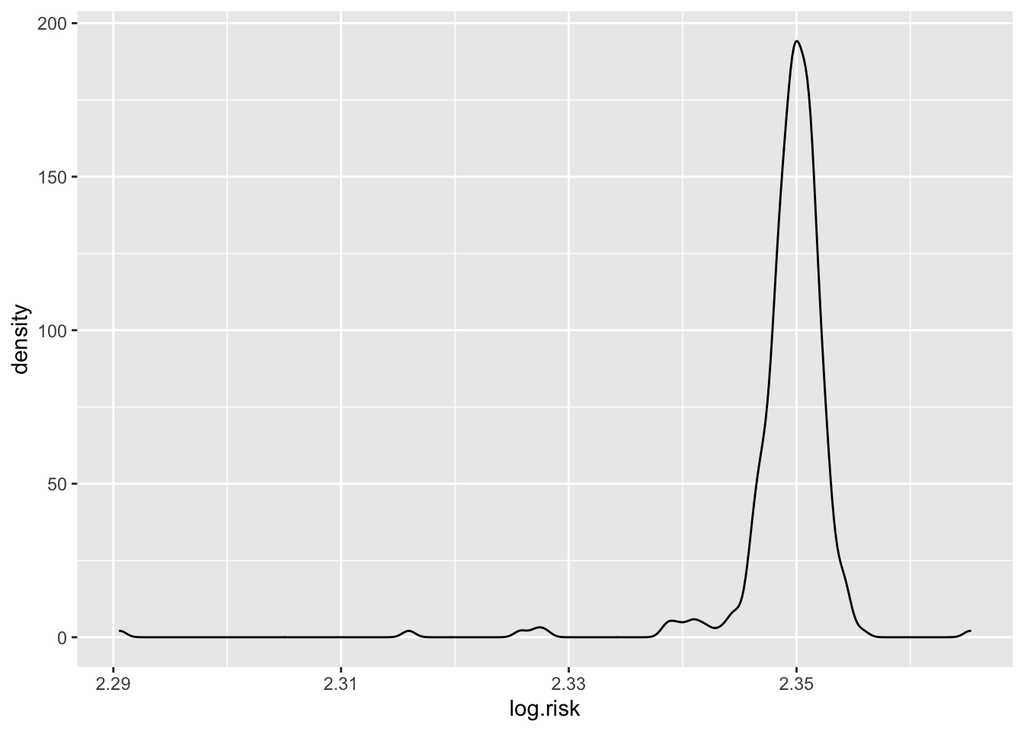

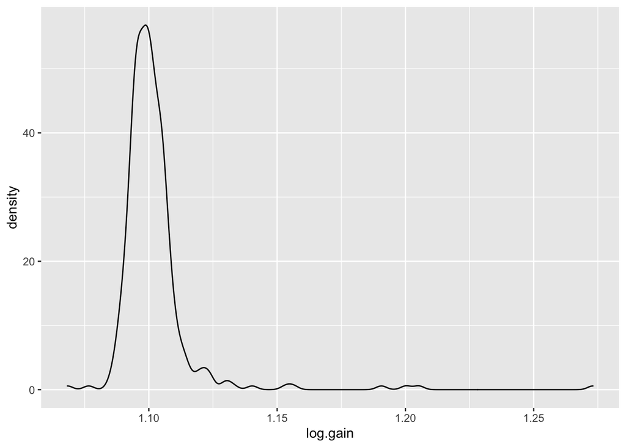

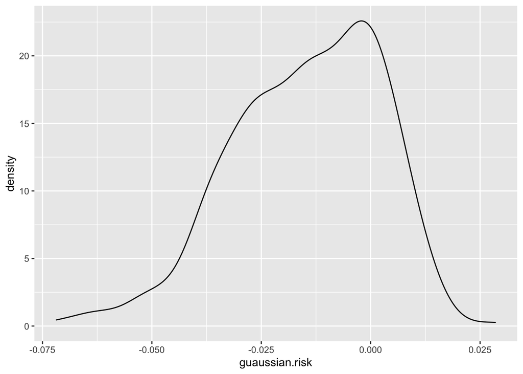

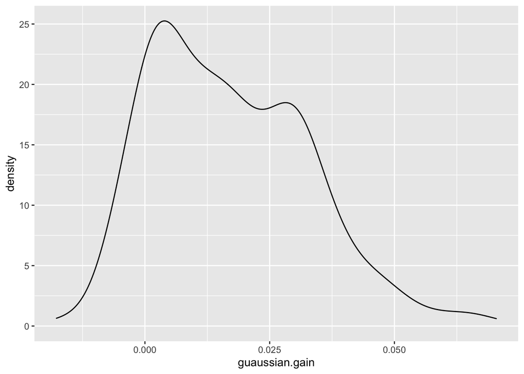

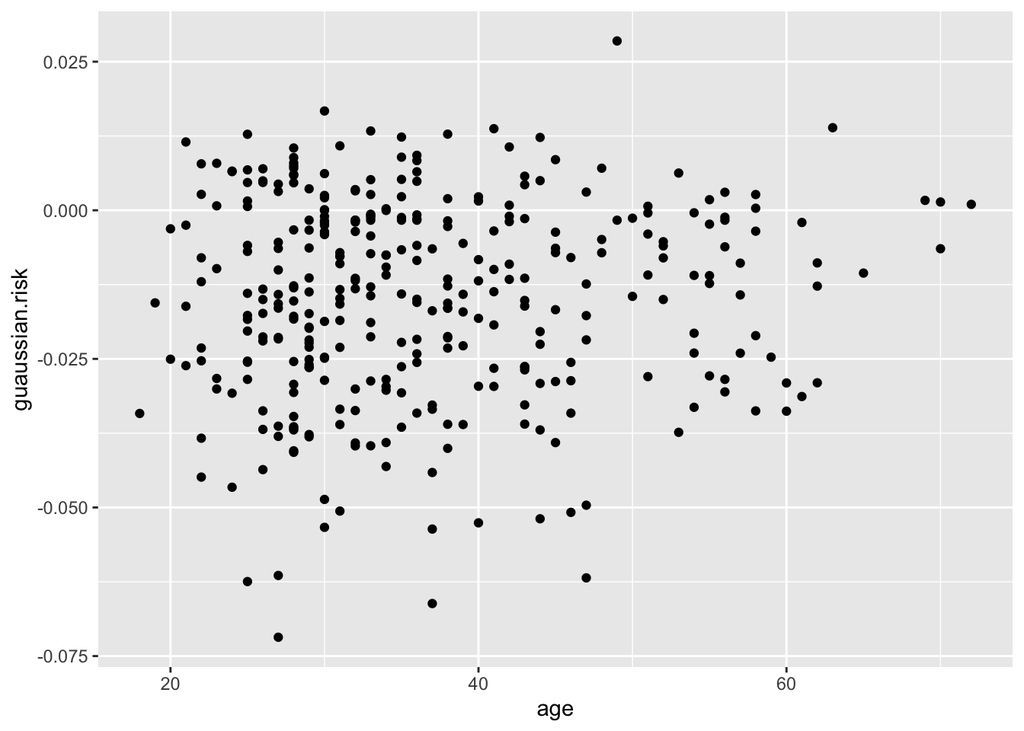

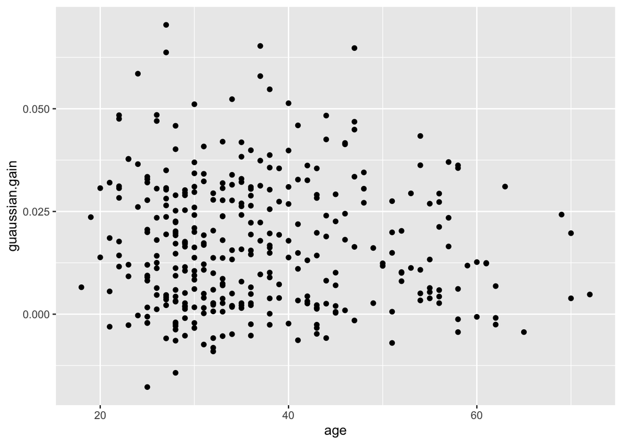

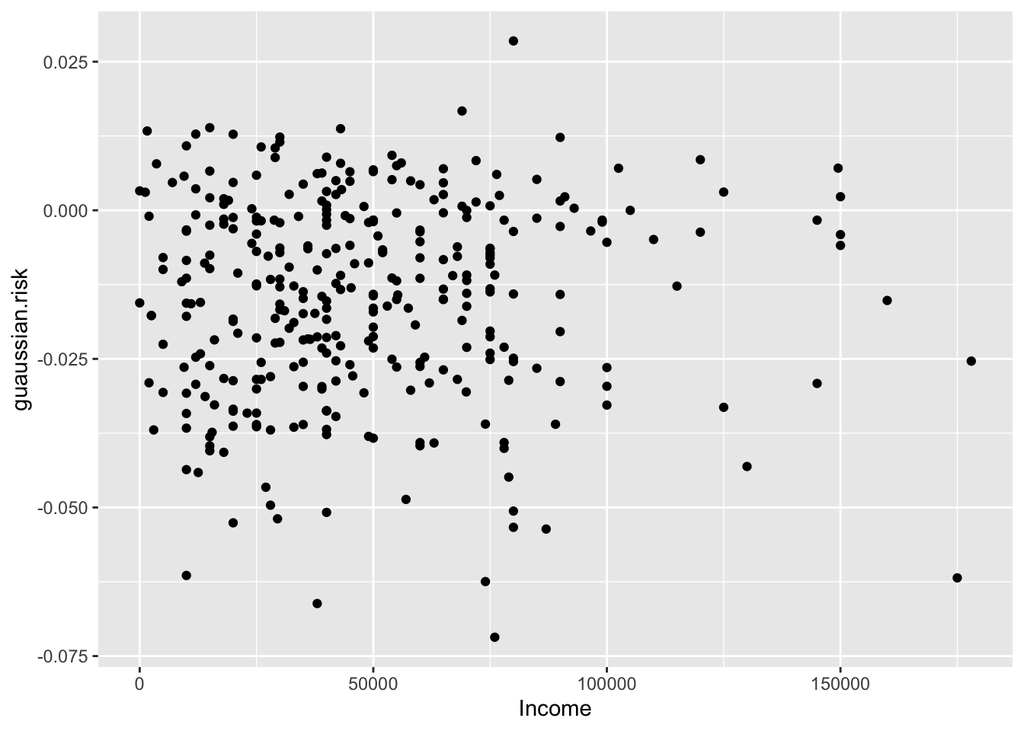

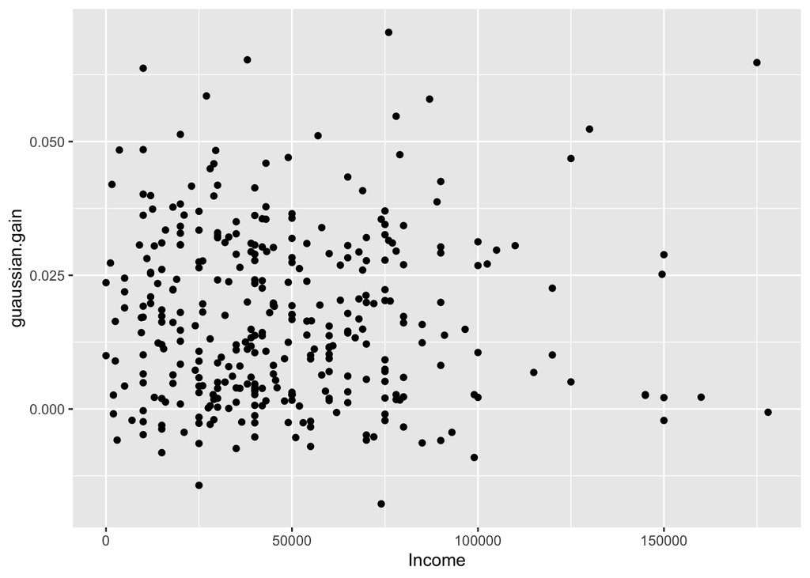

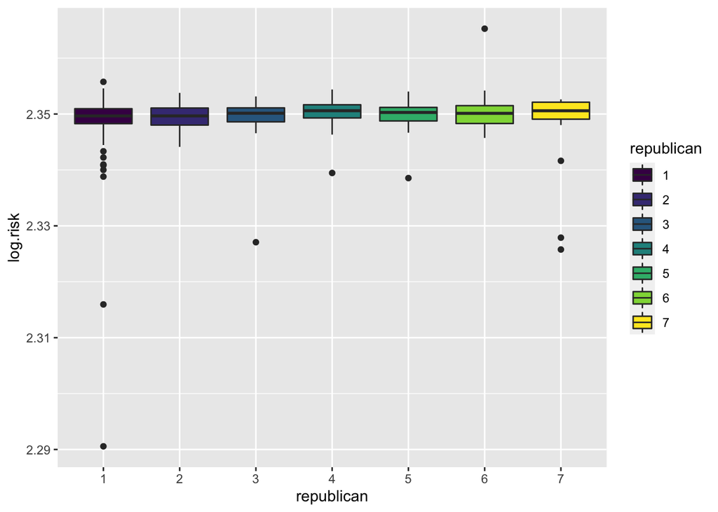

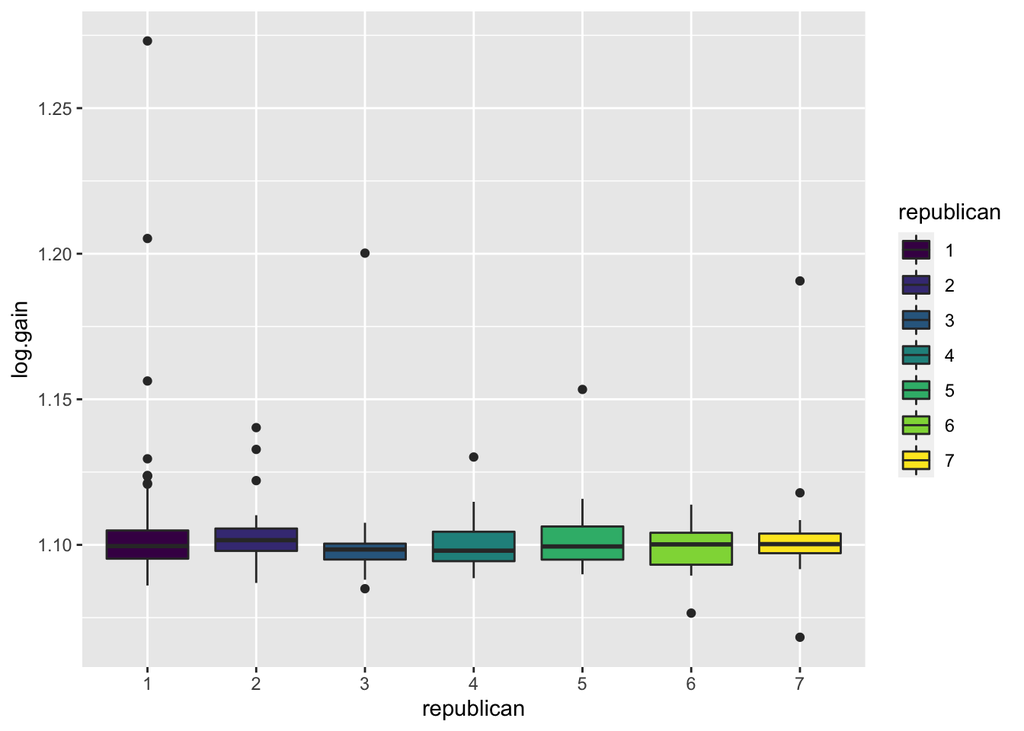

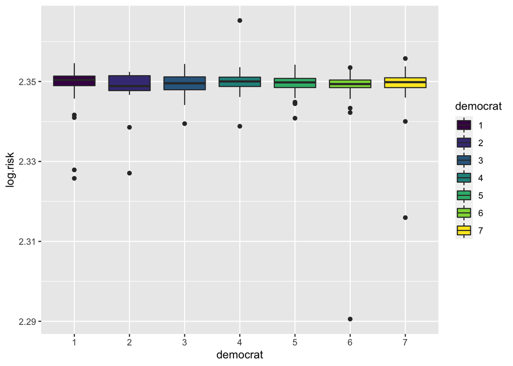

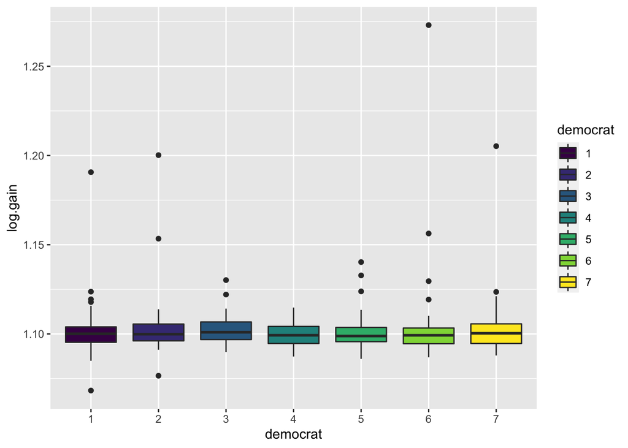

[20 more figures not shown]

```
##
##  Paired t-test
##
## data:  data$guaussian.risk and data$guaussian.gain
## t = -23.514, df = 340, p-value < 2.2e-16
## alternative hypothesis: true difference in means is not equal to 0
## 95 percent confidence interval:
##  -0.03432332 -0.02902429
## sample estimates:
## mean of the differences
##              -0.0316738
```

```r
data %>%
  dplyr::select(guaussian.risk, guaussian.gain, age,Income) ->test

correlation(test)
```

|  | Parameter1 | Parameter2 | r | CI_low | CI_high | t | df | p | Method | n_Obs |
| --- | --- | --- | --- | --- | --- | --- | --- | --- | --- | --- |
| 1 | guaussian.risk | guaussian.gain | -0.1571213477 | -0.25900521 | -0.05177946 | -2.92929469 | 339 | 0.0217645 | Pearson | 341 |
| 2 | guaussian.risk | age | 0.0640867649 | -0.04240782 | 0.16914146 | 1.18239309 | 339 | 1.0000000 | Pearson | 341 |
| 3 | guaussian.risk | Income | 0.0186377627 | -0.08789869 | 0.12475267 | 0.34271063 | 338 | 1.0000000 | Pearson | 340 |
| 4 | guaussian.gain | age | -0.0478213684 | -0.15324897 | 0.05868261 | -0.88149328 | 339 | 1.0000000 | Pearson | 341 |
| 5 | guaussian.gain | Income | 0.0008229377 | -0.10554851 | 0.10717576 | 0.01512953 | 338 | 1.0000000 | Pearson | 340 |
| 6 | age | Income | 0.0562014136 | -0.05046244 | 0.16159764 | 1.03488610 | 338 | 1.0000000 | Pearson | 340 |

```r
lm.risk.age <- lm(guaussian.risk~age, data = test)
lm.risk.income <- lm(guaussian.risk~Income, data = test)

lm.gain.age <- lm(guaussian.gain~age, data = test)
lm.gain.income <- lm(guaussian.gain~Income, data = test)

tab <- map_df(list(lm.risk.age, lm.risk.income, lm.gain.age, lm.gain.income), tidy) %>%
  filter(!term == "(Intercept)")
knitr::kable(tab[c("term", "estimate", "std.error", "statistic", "p.value")])
```

| term | estimate | std.error | statistic | p.value |
| --- | --- | --- | --- | --- |
| age | 9.87e-05 | 8.34e-05 | 1.1823931 | 0.2378784 |
| Income | 0.00e+00 | 0.00e+00 | 0.3427106 | 0.7320292 |
| age | -6.92e-05 | 7.85e-05 | -0.8814933 | 0.3786754 |
| Income | 0.00e+00 | 0.00e+00 | 0.0151295 | 0.9879378 |

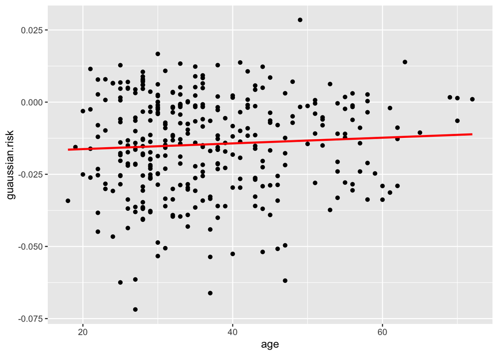

```r
data %>%
  dplyr::select(guaussian.risk, age) ->test
grid <- test %>%
        modelr::data_grid(age)
grid <- grid %>%
  modelr::add_predictions(lm.risk.age)

ggplot(test, aes(age)) +
  geom_point(aes(y = guaussian.risk))+
  geom_line(aes(y= pred),
            grid,
            color="red",
            size = 1
            )
```

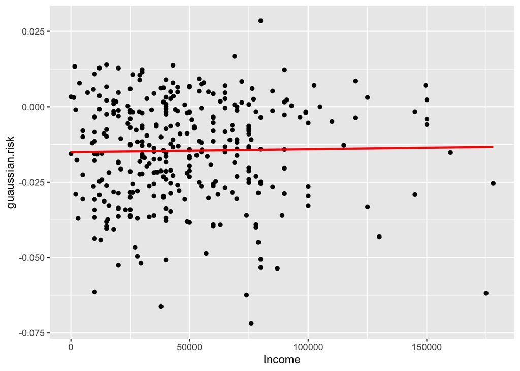

```r
data %>%
  dplyr::select(guaussian.risk, Income) ->test
grid <- test %>%
        modelr::data_grid(Income)
grid <- grid %>%
  modelr::add_predictions(lm.risk.income)

ggplot(test, aes(Income)) +
  geom_point(aes(y = guaussian.risk))+
  geom_line(aes(y= pred),
            grid,
            color="red",
            size = 1
            )
```

Prior studies suggest that medical ethical judgments can be influenced by a person’s political ideology and religious values.

We predict liberals and democrats will be, on average, less sensitive to risks of harm, and more sensitive to benefits,

```r
#####non parametric with log
data %>%
  dplyr::select(log.risk,log.gain, Political_Party) %>%
  filter(Political_Party == "Democrat") -> test

t1 <- wilcox.test(test$log.risk, alternative = "two.sided",  mu = mean(data$log.risk), conf.level = 0.95)
t2 <- wilcox.test(test$log.gain, alternative = "two.sided",  mu = mean(data$log.gain), conf.level = 0.95)

data %>%
  dplyr::select(log.risk,log.gain, Political_Party) %>%
  filter(Political_Party == "Republican") -> test

t3 <-  wilcox.test(test$log.risk, alternative = "two.sided",  mu = mean(data$log.risk), conf.level = 0.95)
t4 <-  wilcox.test(test$log.gain, alternative = "two.sided",  mu = mean(data$log.gain), conf.level = 0.95)

tab <- map_df(list(t1,t2,t3,t4), tidy)
knitr::kable(tab[c("method","statistic", "p.value")])
```

| method | statistic | p.value |
| --- | --- | --- |
| Wilcoxon signed rank test with continuity correction | 8041 | 0.0362394 |
| Wilcoxon signed rank test with continuity correction | 4817 | 0.0013859 |
| Wilcoxon signed rank test with continuity correction | 1685 | 0.0096908 |
| Wilcoxon signed rank test with continuity correction | 969 | 0.1101211 |

```r
#### parametric with guass

data %>%
  dplyr::select(guaussian.risk,guaussian.gain, Political_Party) %>%
  filter(Political_Party == "Democrat") -> test

t1 <- t.test(test$guaussian.risk, alternative = "two.sided",  mu = mean(data$guaussian.risk), conf.level = 0.95,var.equal = T)
t2 <- t.test(test$guaussian.gain, alternative = "two.sided",  mu = mean(data$guaussian.gain), conf.level = 0.95,var.equal = T)

data %>%
  dplyr::select(guaussian.risk,guaussian.gain, Political_Party) %>%
  filter(Political_Party == "Republican") -> test

t3 <-  t.test(test$guaussian.risk, alternative = "two.sided",  mu = mean(data$guaussian.risk), conf.level = 0.95,var.equal = T)
t4 <-  t.test(test$guaussian.gain, alternative = "two.sided",  mu = mean(data$guaussian.gain), conf.level = 0.95,var.equal = T)

tab <- map_df(list(t1,t2,t3,t4), tidy)
knitr::kable(tab[c("estimate", "statistic", "p.value", "parameter", "conf.low",
"conf.high", "method")])
```

| estimate | statistic | p.value | parameter | conf.low | conf.high | method |
| --- | --- | --- | --- | --- | --- | --- |
| -0.0163561 | -1.3741855 | 0.1712707 | 163 | -0.0188377 | -0.0138744 | One Sample t-test |
| 0.0173917 | 0.2728128 | 0.7853424 | 163 | 0.0148803 | 0.0199031 | One Sample t-test |
| -0.0132203 | 0.6040955 | 0.5477613 | 69 | -0.0178726 | -0.0085679 | One Sample t-test |
| 0.0180246 | 0.4593674 | 0.6474143 | 69 | 0.0137692 | 0.0222801 | One Sample t-test |

```r
data$democratSUM <-  C(data$democrat, sum)
data$liberalSUM <-  C(data$liberal, sum)
lm.risk.lib <- lm(guaussian.risk~liberalSUM, data = data)
lm.risk.dem <- lm(guaussian.risk~democratSUM, data = data)

lm.gain.lib <- lm(guaussian.gain~liberalSUM, data = data)
lm.gain.dem <- lm(guaussian.gain~democratSUM, data = data)

tab <- map_df(list(lm.risk.lib, lm.risk.dem, lm.gain.lib, lm.gain.dem), tidy) %>%
  filter(!term == "(Intercept)")
knitr::kable(tab[c("term", "estimate", "std.error", "statistic", "p.value")])
```

| term | estimate | std.error | statistic | p.value |
| --- | --- | --- | --- | --- |
| liberalSUM1 | 0.0026212 | 0.0020432 | 1.2829011 | 0.2004163 |
| liberalSUM2 | -0.0021710 | 0.0029793 | -0.7287124 | 0.4666882 |
| liberalSUM3 | -0.0016117 | 0.0034297 | -0.4699086 | 0.6387270 |
| liberalSUM4 | 0.0033504 | 0.0023184 | 1.4451262 | 0.1493600 |
| liberalSUM5 | -0.0012817 | 0.0022799 | -0.5621865 | 0.5743661 |
| liberalSUM6 | -0.0001679 | 0.0021629 | -0.0776144 | 0.9381813 |
| democratSUM1 | 0.0036611 | 0.0018211 | 2.0103536 | 0.0451973 |
| democratSUM2 | -0.0031774 | 0.0030778 | -1.0323506 | 0.3026548 |
| democratSUM3 | -0.0011414 | 0.0031999 | -0.3566923 | 0.7215474 |
| democratSUM4 | 0.0030797 | 0.0023125 | 1.3317413 | 0.1838533 |
| democratSUM5 | -0.0003730 | 0.0020880 | -0.1786400 | 0.8583287 |
| democratSUM6 | -0.0024602 | 0.0026122 | -0.9418009 | 0.3469753 |
| liberalSUM1 | 0.0014096 | 0.0018882 | 0.7465153 | 0.4558814 |
| liberalSUM2 | -0.0083279 | 0.0027534 | -3.0246430 | 0.0026822 |
| liberalSUM3 | 0.0067263 | 0.0031697 | 2.1220890 | 0.0345659 |
| liberalSUM4 | -0.0018448 | 0.0021426 | -0.8610235 | 0.3898428 |
| liberalSUM5 | 0.0033738 | 0.0021070 | 1.6011958 | 0.1102789 |
| liberalSUM6 | 0.0009705 | 0.0019989 | 0.4855025 | 0.6276383 |
| democratSUM1 | -0.0008121 | 0.0017220 | -0.4715805 | 0.6375341 |
| democratSUM2 | 0.0021836 | 0.0029104 | 0.7502787 | 0.4536151 |
| democratSUM3 | 0.0031524 | 0.0030258 | 1.0418441 | 0.2982375 |
| democratSUM4 | -0.0024358 | 0.0021867 | -1.1139179 | 0.2661154 |
| democratSUM5 | -0.0012328 | 0.0019744 | -0.6243834 | 0.5328021 |
| democratSUM6 | -0.0012578 | 0.0024701 | -0.5092282 | 0.6109285 |

```r
#nonparametric tests
kruskal.test(data$log.risk~data$democrat) # where y1 is numeric and A is a factor
```

```
##
##  Kruskal-Wallis rank sum test
##
## data:  data$log.risk by data$democrat
## Kruskal-Wallis chi-squared = 6.6876, df = 6, p-value = 0.3507
```

```r
kruskal.test(data$log.gain~data$democrat) # where y1 is numeric and A is a factor
```

```
##
##  Kruskal-Wallis rank sum test
##
## data:  data$log.gain by data$democrat
## Kruskal-Wallis chi-squared = 2.8874, df = 6, p-value = 0.8228
```

```r
kruskal.test(data$log.risk~data$liberal) # where y1 is numeric and A is a factor
```

```
##
##  Kruskal-Wallis rank sum test
##
## data:  data$log.risk by data$liberal
## Kruskal-Wallis chi-squared = 4.6897, df = 6, p-value = 0.5842
```

```r
kruskal.test(data$log.gain~data$liberal) # where y1 is numeric and A is a factor
```

```
##
##  Kruskal-Wallis rank sum test
##
## data:  data$log.gain by data$liberal
## Kruskal-Wallis chi-squared = 17.433, df = 6, p-value = 0.007817
```

```r
oneway_test(guaussian.risk~democrat, data=data,
  distribution=approximate(nresample=9999), conf.int =T)
```

```
##
##  Approximative Linear-by-Linear Association Test
##
## data:  guaussian.risk by democrat (1 < 2 < 3 < 4 < 5 < 6 < 7)
## Z = -1.3051, p-value = 0.1875
## alternative hypothesis: two.sided
```

```r
oneway_test(guaussian.gain~democrat, data=data,
  distribution=approximate(nresample=9999), conf.int =T)
```

```
##
##  Approximative Linear-by-Linear Association Test
##
## data:  guaussian.gain by democrat (1 < 2 < 3 < 4 < 5 < 6 < 7)
## Z = -0.080599, p-value = 0.9348
## alternative hypothesis: two.sided
```

```r
oneway_test(guaussian.risk~liberal, data=data,
  distribution=approximate(nresample=9999), conf.int =T)
```

```
##
##  Approximative Linear-by-Linear Association Test
##
## data:  guaussian.risk by liberal (1 < 2 < 3 < 4 < 5 < 6 < 7)
## Z = -0.97745, p-value = 0.3217
## alternative hypothesis: two.sided
```

```r
oneway_test(guaussian.gain~liberal, data=data,
  distribution=approximate(nresample=9999), conf.int =T)
```

```
##
##  Approximative Linear-by-Linear Association Test
##
## data:  guaussian.gain by liberal (1 < 2 < 3 < 4 < 5 < 6 < 7)
## Z = -0.34978, p-value = 0.7316
## alternative hypothesis: two.sided
```

while conservatives and republicans will be more sensitive to risk of harm, and less sensitive to benefits.

```r
data$republicanSUM <- C(data$republican, sum)
data$conservativeSUM <- C(data$conservative, sum)

lm.risk.rep <- lm(guaussian.risk~republicanSUM, data = data)
lm.risk.con <- lm(guaussian.risk~conservativeSUM, data = data)

lm.gain.rep <- lm(guaussian.gain~republicanSUM, data = data)
lm.gain.con <- lm(guaussian.gain~conservativeSUM, data = data)

tab <- map_df(list(lm.risk.rep, lm.risk.con, lm.gain.rep, lm.gain.con), tidy) %>%
  filter(!term == "(Intercept)")
knitr::kable(tab[c("term", "estimate", "std.error", "statistic", "p.value")])
```

| term | estimate | std.error | statistic | p.value |
| --- | --- | --- | --- | --- |
| republicanSUM1 | -0.0030359 | 0.0015855 | -1.9148084 | 0.0563709 |
| republicanSUM2 | -0.0028586 | 0.0027083 | -1.0554836 | 0.2919671 |
| republicanSUM3 | -0.0002892 | 0.0030276 | -0.0955138 | 0.9239640 |
| republicanSUM4 | 0.0038605 | 0.0026767 | 1.4422509 | 0.1501686 |
| republicanSUM5 | -0.0001683 | 0.0031328 | -0.0537078 | 0.9572001 |
| republicanSUM6 | 0.0017533 | 0.0035532 | 0.4934485 | 0.6220200 |
| conservativeSUM1 | -0.0037109 | 0.0016023 | -2.3159668 | 0.0211652 |
| conservativeSUM2 | -0.0029251 | 0.0024688 | -1.1848127 | 0.2369339 |
| conservativeSUM3 | 0.0006724 | 0.0027347 | 0.2458743 | 0.8059305 |
| conservativeSUM4 | 0.0027994 | 0.0026341 | 1.0627862 | 0.2886467 |
| conservativeSUM5 | 0.0011784 | 0.0025463 | 0.4628094 | 0.6438023 |
| conservativeSUM6 | 0.0028245 | 0.0035185 | 0.8027578 | 0.4226856 |
| republicanSUM1 | 0.0003635 | 0.0014944 | 0.2432321 | 0.8079749 |
| republicanSUM2 | 0.0047856 | 0.0025527 | 1.8747131 | 0.0617047 |
| republicanSUM3 | -0.0032461 | 0.0028537 | -1.1375356 | 0.2561298 |
| republicanSUM4 | -0.0008130 | 0.0025230 | -0.3222411 | 0.7474717 |
| republicanSUM5 | 0.0001987 | 0.0029529 | 0.0672818 | 0.9463976 |
| republicanSUM6 | -0.0028897 | 0.0033491 | -0.8628338 | 0.3888480 |
| conservativeSUM1 | 0.0003931 | 0.0015151 | 0.2594759 | 0.7954279 |
| conservativeSUM2 | 0.0021247 | 0.0023345 | 0.9101214 | 0.3634148 |
| conservativeSUM3 | 0.0029219 | 0.0025859 | 1.1299449 | 0.2593103 |
| conservativeSUM4 | -0.0014566 | 0.0024907 | -0.5848268 | 0.5590591 |
| conservativeSUM5 | -0.0010315 | 0.0024077 | -0.4284236 | 0.6686189 |
| conservativeSUM6 | -0.0046356 | 0.0033270 | -1.3933125 | 0.1644518 |

```r
#nonparametric tests
kruskal.test(data$log.risk~data$republican) # where y1 is numeric and A is a factor
```

```
##
##  Kruskal-Wallis rank sum test
##
## data:  data$log.risk by data$republican
## Kruskal-Wallis chi-squared = 8.1826, df = 6, p-value = 0.225
```

```r
kruskal.test(data$log.gain~data$republican) # where y1 is numeric and A is a factor
```

```
##
##  Kruskal-Wallis rank sum test
##
## data:  data$log.gain by data$republican
## Kruskal-Wallis chi-squared = 6.1985, df = 6, p-value = 0.4013
```

```r
kruskal.test(data$log.risk~data$conservative) # where y1 is numeric and A is a factor
```

```
##
##  Kruskal-Wallis rank sum test
##
## data:  data$log.risk by data$conservative
## Kruskal-Wallis chi-squared = 8.6639, df = 6, p-value = 0.1934
```

```r
kruskal.test(data$log.gain~data$conservative) # where y1 is numeric and A is a factor
```

```
##
##  Kruskal-Wallis rank sum test
##
## data:  data$log.gain by data$conservative
## Kruskal-Wallis chi-squared = 5.5243, df = 6, p-value = 0.4785
```

```r
oneway_test(log.risk~republican, data=data,
  distribution=approximate(nresample=9999), conf.int =T)
```

```
##
##  Approximative Linear-by-Linear Association Test
##
## data:  log.risk by republican (1 < 2 < 3 < 4 < 5 < 6 < 7)
## Z = 0.84153, p-value = 0.4111
## alternative hypothesis: two.sided
```

```r
oneway_test(log.gain~republican, data=data,
  distribution=approximate(nresample=9999), conf.int =T)
```

```
##
##  Approximative Linear-by-Linear Association Test
##
## data:  log.gain by republican (1 < 2 < 3 < 4 < 5 < 6 < 7)
## Z = -0.45148, p-value = 0.6674
## alternative hypothesis: two.sided
```

```r
oneway_test(log.risk~conservative, data=data,
  distribution=approximate(nresample=9999), conf.int =T)
```

```
##
##  Approximative Linear-by-Linear Association Test
##
## data:  log.risk by conservative (1 < 2 < 3 < 4 < 5 < 6 < 7)
## Z = 0.95935, p-value = 0.346
## alternative hypothesis: two.sided
```

```r
oneway_test(log.gain~conservative, data=data,
  distribution=approximate(nresample=9999), conf.int =T)
```

```
##
##  Approximative Linear-by-Linear Association Test
##
## data:  log.gain by conservative (1 < 2 < 3 < 4 < 5 < 6 < 7)
## Z = -0.52565, p-value = 0.6163
## alternative hypothesis: two.sided
```

Testing for means differences between dems and reps

```r
data %>%
  dplyr::select(user_id, Political_Party, log.risk, log.gain) -> subset
subset <- subset(subset, Political_Party != "Independent")
subset <- subset(subset, Political_Party != "Other")

# Sort by beta type then user_id so that the t test function reads it
subset <- subset[order(subset$Political_Party, subset$user_id), ]

# Welch t-test
#tests differences between rep and dems on each of our responses
t1 <- t.test(log.risk ~ Political_Party, subset, var.equal=TRUE)
t2 <- t.test(log.gain ~ Political_Party, subset, var.equal=TRUE)

#create table
tab <- map_df(list(t1, t2), tidy)
knitr::kable(tab[c("method","estimate", "statistic", "conf.low", "conf.high", "p.value")])
```

| method | estimate | statistic | conf.low | conf.high | p.value |
| --- | --- | --- | --- | --- | --- |
| Two Sample t-test | -0.0001901 | -0.2309971 | -0.0018116 | 0.0014314 | 0.8175206 |
| Two Sample t-test | -0.0005298 | -0.1996756 | -0.0057575 | 0.0046979 | 0.8419092 |

```r
#nonparametric tests
wilcox.test(log.risk~Political_Party, data = subset)
```

```
##
##  Wilcoxon rank sum test with continuity correction
##
## data:  log.risk by Political_Party
## W = 4884, p-value = 0.07118
## alternative hypothesis: true location shift is not equal to 0
```

```r
wilcox.test(log.gain~Political_Party, data = subset)
```

```
##
##  Wilcoxon rank sum test with continuity correction
##
## data:  log.gain by Political_Party
## W = 5584, p-value = 0.7429
## alternative hypothesis: true location shift is not equal to 0
```

```r
coin::wilcox_test(log.risk~Political_Party, subset, distribution="exact")
```

```
##
##  Exact Wilcoxon-Mann-Whitney Test
##
## data:  log.risk by Political_Party (Democrat, Republican)
## Z = -1.8054, p-value = 0.07113
## alternative hypothesis: true mu is not equal to 0
```

```r
coin::wilcox_test(log.gain~Political_Party, subset, distribution="exact")
```

```
##
##  Exact Wilcoxon-Mann-Whitney Test
##
## data:  log.gain by Political_Party (Democrat, Republican)
## Z = -0.32901, p-value = 0.7435
## alternative hypothesis: true mu is not equal to 0
```

Consistent with the literature, we also predict that those who are more religious will be, on average, more sensitive to risks of harm.

```r
data %>%
   dplyr::select(user_id, guaussian.risk, guaussian.gain, ReligionRaised, ReligionNow, Religiosity, Spirituality,
AttendChurch, ReligiousActivity) -> data.religious

#we need a change variable if you changed relgion
data.religious <- mutate(data.religious, ReligionChanged = data.religious$ReligionRaised == data.religious$ReligionNow)
data.religious$ReligionChanged <- factor(data.religious$ReligionChanged, labels = c("Yes","No"))

religious <- data.matrix(data.religious[,c(6:10)]) - 1

#Check for number of factors
religious.cov <- psych::polychoric(religious)$rho
```

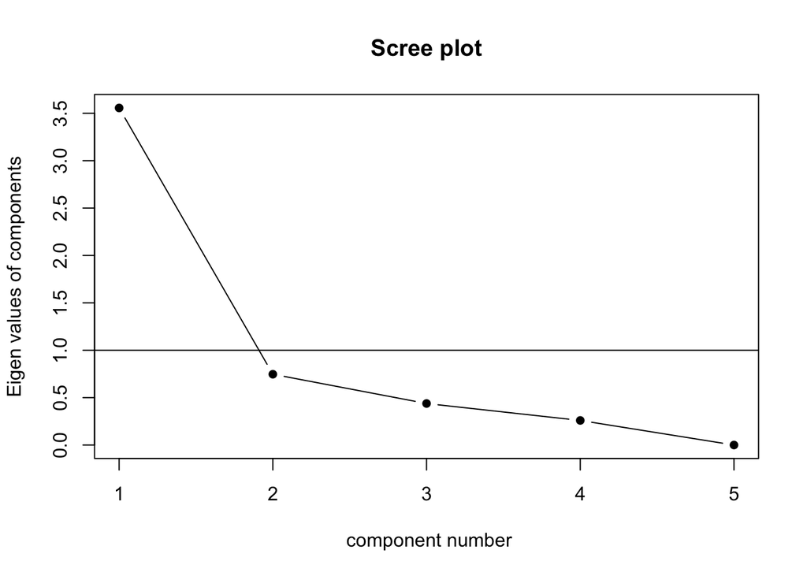

```r
evals <- eigen(religious.cov)$values
scree(religious.cov, factors = F)
```

```r
(evals/sum(evals)*100)[1:5]
```

```
## [1] 7.112091e+01 1.493511e+01 8.759082e+00 5.184901e+00 1.980874e-09
```

```r
religious.efa <- fa(religious, nfactors = 1, rotate = "oblimin", fm ="ml", cor = "poly", scores = "regression")
print(religious.efa$loadings, cutoff = "0.3")
```

```
##
## Loadings:
##                   ML1
## Religiosity       0.998
## Spirituality      0.732
## AttendChurch      0.816
## ReligiousActivity 0.767
## ReligionChanged   0.742
##
##                  ML1
## SS loadings    3.336
## Proportion Var 0.667
```

```r
religious.factor_scores<- religious.efa$scores

data.religious <- cbind(data.religious, religious.factor_scores)
colnames(data.religious) <- c("user_id", "guaussian.risk", "guaussian.gain", "ReligionRaised", "ReligionNow",
"Religiosity", "Spirituality", "AttendChurch", "ReligiousActivity",
"ReligionChanged", "ReligiousFactor")

#test
correlation::correlation(data.religious)
```

|  | Parameter1 | Parameter2 | r | CI_low | CI_high | t | df | p | Method | n_Obs |
| --- | --- | --- | --- | --- | --- | --- | --- | --- | --- | --- |
| 1 | guaussian.risk | guaussian.gain | -0.15712135 | -0.25900521 | -0.05177946 | -2.929295 | 339 | 0.007254834 | Pearson | 341 |
| 2 | guaussian.risk | ReligiousFactor | 0.19408965 | 0.08973343 | 0.29423048 | 3.642842 | 339 | 0.000935458 | Pearson | 341 |
| 3 | guaussian.gain | ReligiousFactor | -0.05359517 | -0.15889665 | 0.05291195 | -0.988212 | 339 | 0.323753610 | Pearson | 341 |

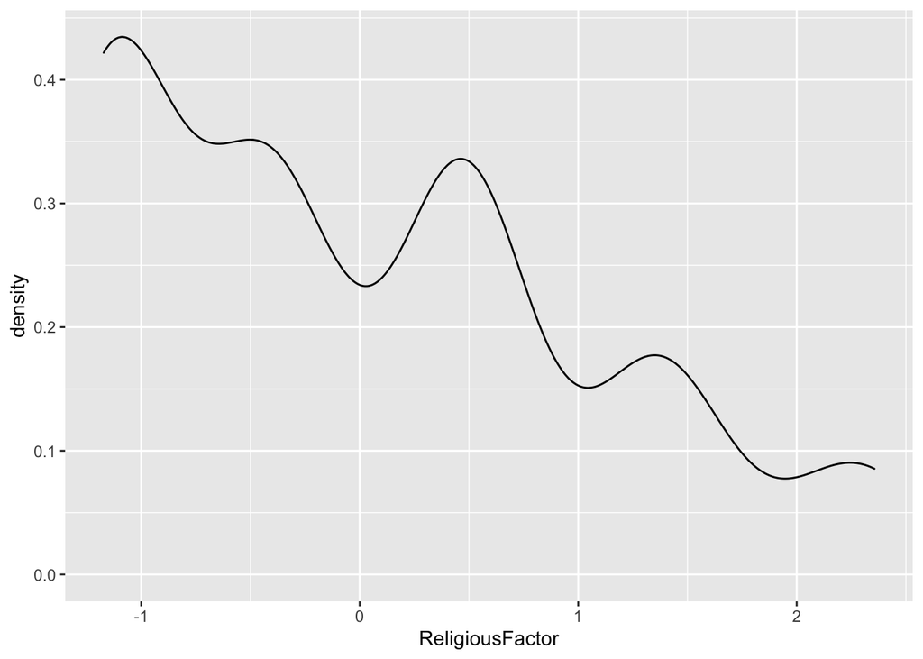

```r
ggplot(data.religious, aes(ReligiousFactor)) + geom_density()
```

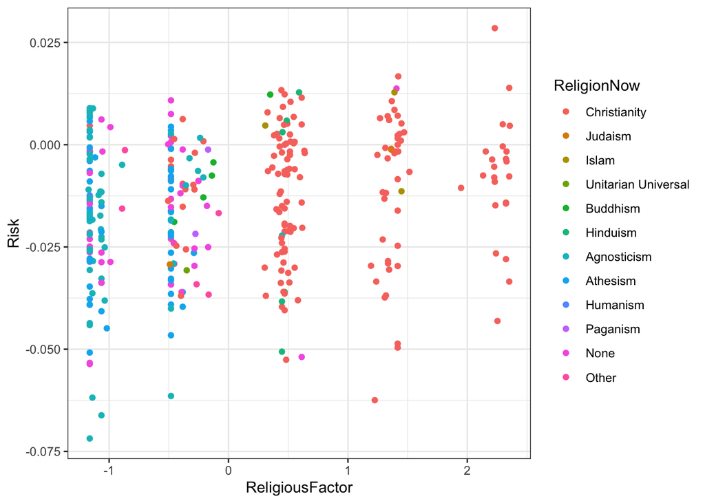

```r
ggplot(data.religious, aes(ReligiousFactor, guaussian.risk, color = ReligionNow, group = ReligionNow)) +
  geom_point() +
  labs(x="ReligiousFactor", y="Risk") +
  theme_bw()
```

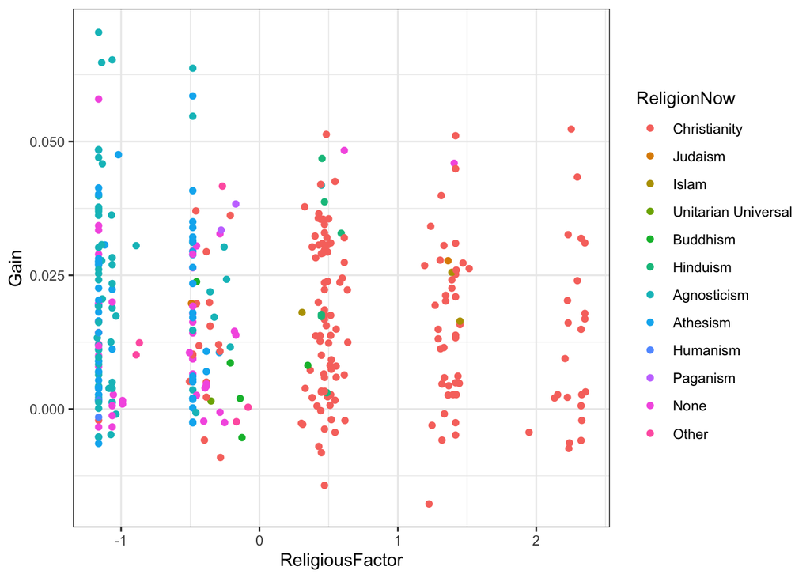

```r
ggplot(data.religious, aes(ReligiousFactor, guaussian.gain, color = ReligionNow, group = ReligionNow))+
  geom_point()+
  labs(x="ReligiousFactor", y="Gain") +
  theme_bw()
```

```r
summary(data.religious$ReligionNow)
```

```
##        Christianity             Judaism               Islam Unitarian Universal
##                 154                   2                   3                   1
##            Buddhism            Hinduism         Agnosticism            Athesism
##                   5                   6                  61                  57
##            Humanism            Paganism                None               Other
##                   2                   2                  43                   5
```

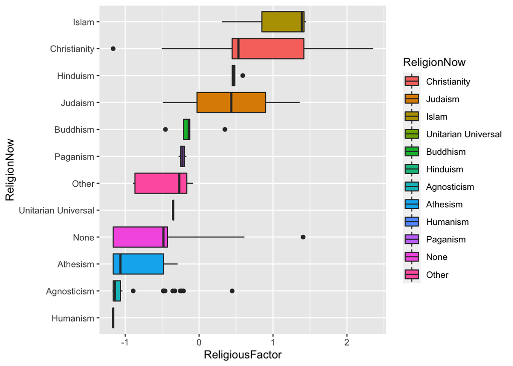

```r
ggplot(data.religious) +
  geom_boxplot(aes(reorder(ReligionNow, ReligiousFactor, FUN = median),ReligiousFactor, fill = ReligionNow)) +
  coord_flip()+
  labs(x="ReligionNow", y="ReligiousFactor")
```

```r
lm.risk.relig <- lm(guaussian.risk~ReligiousFactor, data = data.religious)
lm.gain.relig <- lm(guaussian.gain~ReligiousFactor, data = data.religious)

tab <- map_df(list(lm.risk.relig, lm.gain.relig), tidy) %>%
  filter(!term == "(Intercept)")
knitr::kable(tab[c("term", "estimate", "std.error", "statistic", "p.value")])
```

| term | estimate | std.error | statistic | p.value |
| --- | --- | --- | --- | --- |
| ReligiousFactor | 0.0031415 | 0.0008624 | 3.642842 | 0.0003118 |
| ReligiousFactor | -0.0008158 | 0.0008255 | -0.988212 | 0.3237536 |

```r
data.religious$ReligionNowSUM <-  C(data.religious$ReligionNow, sum)

lm.risk.relig.control <- lm(guaussian.risk~ ReligiousFactor + ReligionNowSUM, data = data.religious)
lm.gain.relig.control <- lm(guaussian.gain~ ReligiousFactor + ReligionNowSUM, data = data.religious)

tab <- map_df(list(lm.risk.relig.control, lm.gain.relig.control), tidy) %>%
  filter(!term == "(Intercept)")
knitr::kable(tab[c("term", "estimate", "std.error", "statistic", "p.value")])
```

| term | estimate | std.error | statistic | p.value |
| --- | --- | --- | --- | --- |
| ReligiousFactor | 0.0013334 | 0.0014892 | 0.8953615 | 0.3712505 |
| ReligionNowSUM1 | 0.0027704 | 0.0032469 | 0.8532337 | 0.3941524 |
| ReligionNowSUM2 | -0.0006081 | 0.0110852 | -0.0548576 | 0.9562853 |
| ReligionNowSUM3 | 0.0158551 | 0.0093201 | 1.7011799 | 0.0898569 |
| ReligionNowSUM4 | -0.0150270 | 0.0154141 | -0.9748874 | 0.3303345 |
| ReligionNowSUM5 | 0.0090954 | 0.0072690 | 1.2512527 | 0.2117340 |
| ReligionNowSUM6 | -0.0026259 | 0.0067867 | -0.3869149 | 0.6990701 |
| ReligionNowSUM7 | -0.0026013 | 0.0034478 | -0.7544730 | 0.4511066 |
| ReligionNowSUM8 | -0.0010468 | 0.0034294 | -0.3052418 | 0.7603756 |
| ReligionNowSUM9 | -0.0037353 | 0.0111495 | -0.3350218 | 0.7378228 |
| ReligionNowSUM10 | 0.0040108 | 0.0110498 | 0.3629774 | 0.7168555 |
| ReligionNowSUM11 | -0.0010193 | 0.0035459 | -0.2874619 | 0.7739402 |
| ReligiousFactor | 0.0010252 | 0.0013989 | 0.7328507 | 0.4641729 |
| ReligionNowSUM1 | -0.0022230 | 0.0030500 | -0.7288337 | 0.4666234 |
| ReligionNowSUM2 | 0.0066532 | 0.0104130 | 0.6389312 | 0.5233136 |
| ReligionNowSUM3 | 0.0023054 | 0.0087549 | 0.2633224 | 0.7924674 |
| ReligionNowSUM4 | -0.0147775 | 0.0144795 | -1.0205831 | 0.3082042 |
| ReligionNowSUM5 | -0.0090701 | 0.0068282 | -1.3283222 | 0.1849952 |
| ReligionNowSUM6 | 0.0089539 | 0.0063752 | 1.4044925 | 0.1611185 |
| ReligionNowSUM7 | 0.0066439 | 0.0032388 | 2.0513685 | 0.0410249 |
| ReligionNowSUM8 | 0.0019864 | 0.0032214 | 0.6166151 | 0.5379164 |
| ReligionNowSUM9 | -0.0153643 | 0.0104735 | -1.4669791 | 0.1433399 |
| ReligionNowSUM10 | 0.0194938 | 0.0103798 | 1.8780544 | 0.0612607 |
| ReligionNowSUM11 | -0.0008644 | 0.0033309 | -0.2595164 | 0.7953997 |

# Exploration

Aim 2) To explore the relationship between existing moral intuitions and judgments about abstract technologies involving a risk of harm and likelihood of gain.

Consistent with MFT we hypothesize that higher scores on foundations of Authority, Loyalty, and Sanctity will be more risk averse than those who score high on Harm and Fairness.

Winsorization began as a way to "robustify" the sample mean, which is sensitive to extreme values. To obtain the Winsorized mean, you sort the data and replace the smallest k values by the (k+1)st smallest value. You do the same for the largest values, replacing the k largest values with the (k+1)st largest value. The mean of this new set of numbers is called the Winsorized mean. If the data are from a symmetric population, the Winsorized mean is a robust unbiased estimate of the population mean.